# Cvičení 10: Exploratory Data Analysis - Vizualizace dat

MPE_AVED - Analýza a vizualizace ekonomických dat

Dana Kozáková

2025-12-03

# 1 Úvod

**Základní zdroj**

Claus O. Wilke: Fundamentals of Data Visualization (kapitoly 6-14, 16) https://clauswilke.com/dataviz/visualizing-amounts.html https://is.muni.cz/auth/el/econ/podzim2025/MPE_AVED/um/exercises/ex10.html

Cvičení na **exploratorní analýzu dat (EDA)** s důrazem na vizualizaci:

- **Vizualizovat rozdělení diskrétních proměnných** - sloupcové grafy
- **Vizualizovat rozdělení spojitých proměnných** - histogramy, hustotní grafy, box ploty
- **Analyzovat vztahy mezi proměnnými** - scatter ploty, korelace
- **Identifikovat vzory a anomálie** v datech
- **Vytvářet informativní a profesionální vizualizace**

# 2 Načítání balíků

```r
# Načtěte potřebné balíky
library(tidyverse)
```

# 3 Vizualizace rozdělení diskrétní proměnné (množství)

Diskrétní (kategorické) proměnné mají omezený počet hodnot. Pro jejich vizualizaci používáme především sloupcové grafy.

## 3.1 Načtení dat

```r
# Načtěte data pro analýzu diskrétních proměnných
dfd <- readr::read_csv("https://is.muni.cz/go/t0tt37")

# Prozkoumejte strukturu dat
mean(dfd$x)
```

```
#> [1] 54.26327
```

```r
# cez lapply
dfd |> lapply(mean)
```

```
#> $x
#> [1] 54.26327
#>
#> $y
#> [1] 47.83225
```

```r
# nebo cez map v purr (purr sucastou tidyverse), je to ekvivalentne, kedysi bol map trochu rychlejší
dfd |> map(mean)
```

```
#> $x
#> [1] 54.26327
#>
#> $y
#> [1] 47.83225
```

```r
# krajsi vystup
dfd |>
  map(mean) |>
  as.tibble()
```

```
#> # A tibble: 1 × 2
#>       x     y
#>   <dbl> <dbl>
#> 1  54.3  47.8
```

```r
# ale chceme len pre numericke stlpce
is.numeric(dfd)
```

```
#> [1] FALSE
```

```r
is.numeric(dfd$x)
```

```
#> [1] TRUE
```

```r
lapply(dfd, is.numeric)
```

```
#> $x
#> [1] TRUE
#>
#> $y
#> [1] TRUE
```

```r
unlist(lapply(dfd, is.numeric)) # maska, ktora vyberie len numericke stlpce
```

```
#>    x    y
#> TRUE TRUE
```

```r
dfd[unlist(lapply(dfd, is.numeric))] |>
  map(mean) |>
  as.tibble()
```

```
#> # A tibble: 1 × 2
#>       x     y
#>   <dbl> <dbl>
#> 1  54.3  47.8
```

```r
# trochu krajsi zapis predchadzajuceho
#dfd[map_lgl(dfd, is.numeric)] |>
#  map_dbl(dfd) |>
#  as.tibble()
```

funguje to preto, ze dataframe aj tibble sú specialne pripady listu a obe funkcie `map` aj `lapply` sú iterátory cez položky listu (= stĺpce)

**Funkce `summarise`** - musí mať jeden výstup (pri priemere je to ok, pri kvantiloch už nemusí)

```r
# riesenie pomocou tidyverse, ale toto nebude fungovat, ak tam bude NA hodnota
dfd |>
  summarise(
    across(
      where(is.numeric),
      mean
    )
  )
```

```
#> # A tibble: 1 × 2
#>       x     y
#>   <dbl> <dbl>
#> 1  54.3  47.8
```

```r
# Anonymní (lambda) funkcie
# 1. sposob:
dfd |>
  summarise(
    across(
      where(is.numeric),
      ~ mean(., na.rm = TRUE) # len pre vynechanie NA hodnot
    )
  )
```

```
#> # A tibble: 1 × 2
#>       x     y
#>   <dbl> <dbl>
#> 1  54.3  47.8
```

```r
# 2. sposob:
dfd |>
  summarise(
    across(
      where(is.numeric),
      \(x) mean(x, na.rm = TRUE) # \(x) je oznacenie vstupneho parametra
    )
  )
```

```
#> # A tibble: 1 × 2
#>       x     y
#>   <dbl> <dbl>
#> 1  54.3  47.8
```

```r
# 3. sposob: ak je funkcia zlozitejsia - na viac riadkov
dfd |>
  summarise(
    across(
      where(is.numeric),
      \(x){ # medzi {} je telo funkcie
        na.omit(x) |>
          mean()
      }
    )
  )
```

```
#> # A tibble: 1 × 2
#>       x     y
#>   <dbl> <dbl>
#> 1  54.3  47.8
```

```r
# alebo vlastna funkcia, nie lambda funkcia
mean_na <- function(x) mean(x, na.rm = TRUE)

dfd |>
  summarise(
    across(
      where(is.numeric),
      mean_na
    )
  )
```

```
#> # A tibble: 1 × 2
#>       x     y
#>   <dbl> <dbl>
#> 1  54.3  47.8
```

**Funkcia `reframe`** namiesto summarise

```r
# Využití experimentální fuknce reframe (summarise co vrací i větší počet řádků na grupu):
dfd |>
  reframe(
    across(
      where(is.numeric),
      \(x){
        # Vytvářím pojmenovaný vektor
        c(
          "Mean" = mean(x),
          "Sd" = sd(x)
        )
      }
    )
  )
```

```
#> # A tibble: 2 × 2
#>       x     y
#>   <dbl> <dbl>
#> 1  54.3  47.8
#> 2  16.8  26.9
```

**Riešenie so základnými funkciami**

```r
dfd |>
  select(
    where(is.numeric)
  ) |>
  pivot_longer(
    everything()
    ) |>
  group_by(name) |>
  summarise(
    Mean = mean(value),
    Sd = sd(value)
  )
```

```
#> # A tibble: 2 × 3
#>   name   Mean    Sd
#>   <chr> <dbl> <dbl>
#> 1 x      54.3  16.8
#> 2 y      47.8  26.9
```

**Grafy**

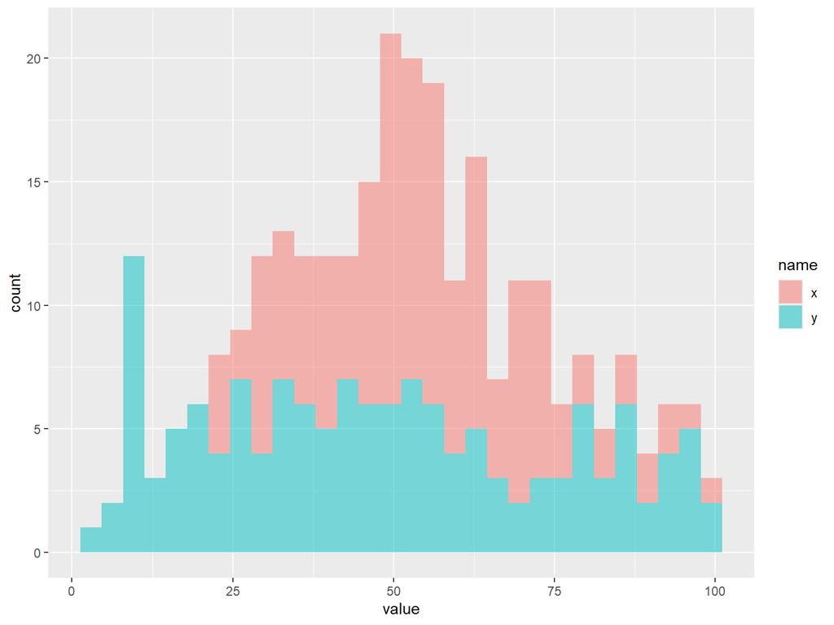

```r
dfd |>
  pivot_longer(everything()) |>
  ggplot(
    aes(x = value, fill = name)
  ) +
  geom_histogram(
    alpha = 0.5 # pruhy nad sebou, default je "stack"
  )
```

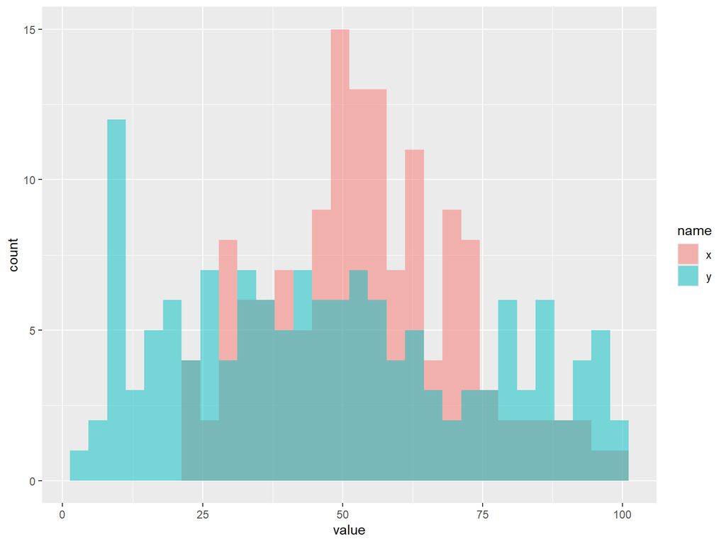

```r
dfd |>
  pivot_longer(everything()) |>
  ggplot(
    aes(x = value, fill = name)
  ) +
  geom_histogram(
    alpha = 0.5,
    position = "identity"
  )
```

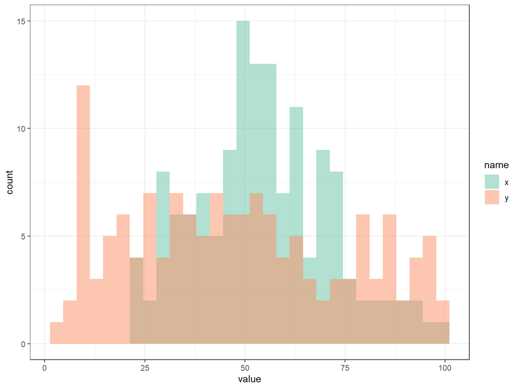

```r
# trochu krajsie
dfd |>
  pivot_longer(everything()) |>
  ggplot(aes(x = value, fill = name)) +
  geom_histogram(
    alpha = 0.5,
    position = "identity"
  ) +
  scale_fill_brewer(palette = "Set2") +
  theme_bw()
```

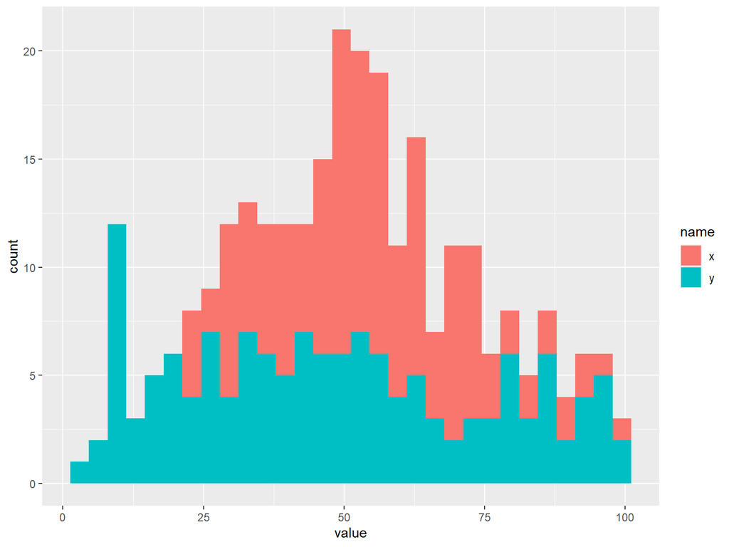

```r
# trochu divocina so stat_bin(), takto sa to nepouziva
dfd |>
  pivot_longer(everything()) |>
  ggplot(aes(x = value, fill = name)) +
  stat_bin()
```

**Pouzitie jednej vlastnosti do viacerych parametrov**

- x a y sa rozlisuje aj podla farby, aj podla typu hranicnej ciary

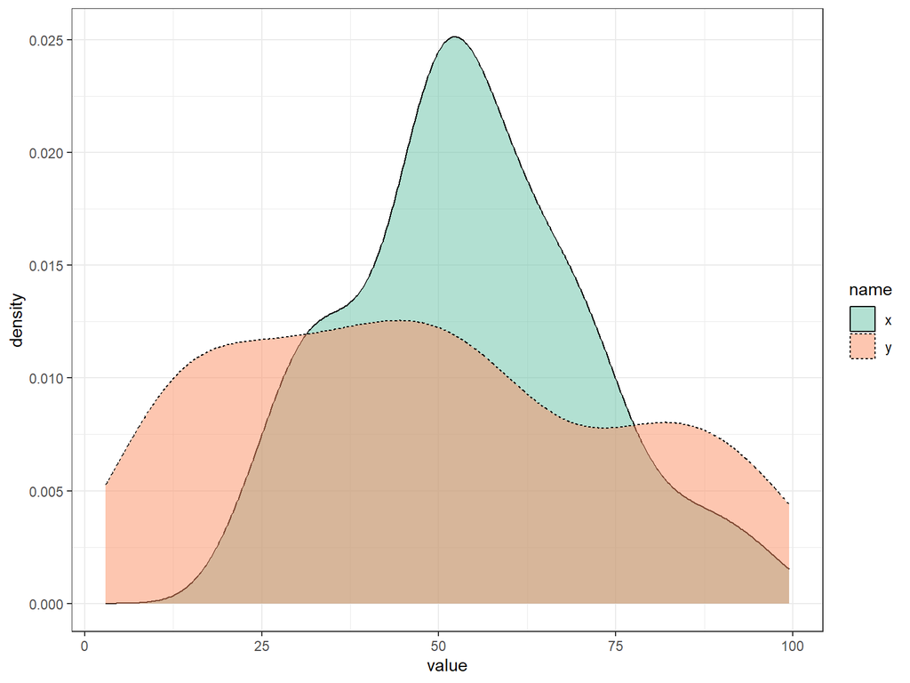

```r
dfd |>
  pivot_longer(everything()) |>
  ggplot(
    aes(x = value, fill = name, linetype = name)
  ) +
  geom_density(
    alpha = 0.5
  ) +
  scale_fill_brewer(
    palette = "Set2"
  ) +
  theme_bw()
```

**Graf rug**

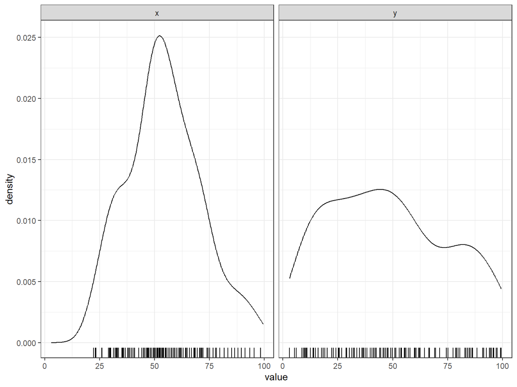

```r
dfd |>
  pivot_longer(everything()) |>
  ggplot(
    aes(x = value)
  ) +
  geom_density(
    alpha = 0.5
  ) +
  geom_rug() +
  facet_wrap(~ name) +
  theme_bw()
```

**Boxplot**

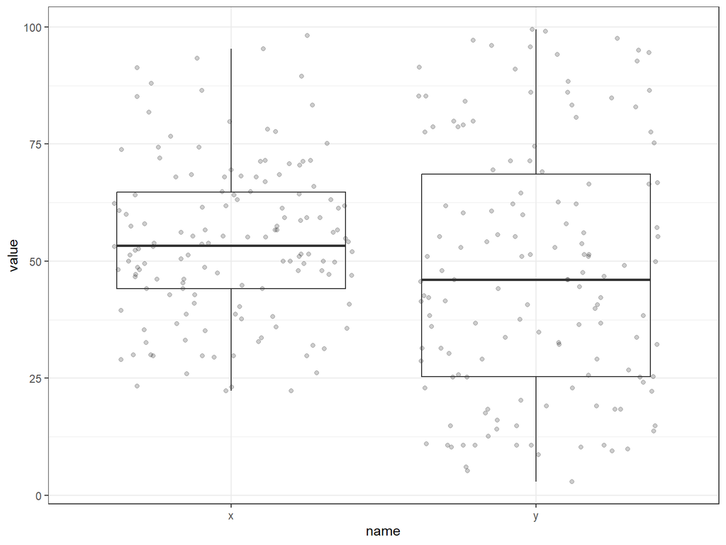

```r
set.seed(42)

dfd |>
  pivot_longer(everything()) |>
  ggplot(
    aes(y = value, x = name)
  ) +
  geom_jitter(
    height = 0,
    alpha = 0.2
    ) +
  geom_boxplot(
    outliers = FALSE,
    fill = NA
  ) +
  theme_bw()
```

**GGplot s gghalves**

- ale tu asi nemame kontrolu nad tym, ci sa to neprekryva

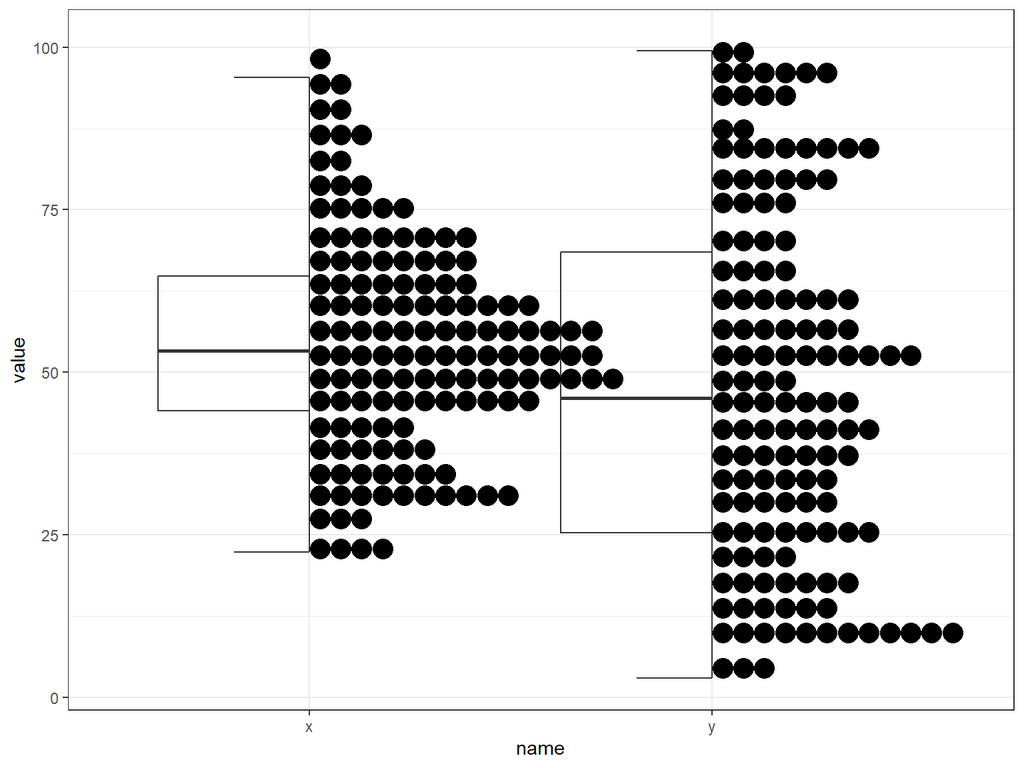

```r
library(gghalves)
set.seed(42)

dfd |>
  pivot_longer(everything()) |>
  ggplot(
    aes(y = value, x = name)
  ) +
  geom_half_boxplot(
    outliers = FALSE,
    fill = NA
  ) +
  geom_half_dotplot() +
  theme_bw()
```

**What’s the point?**

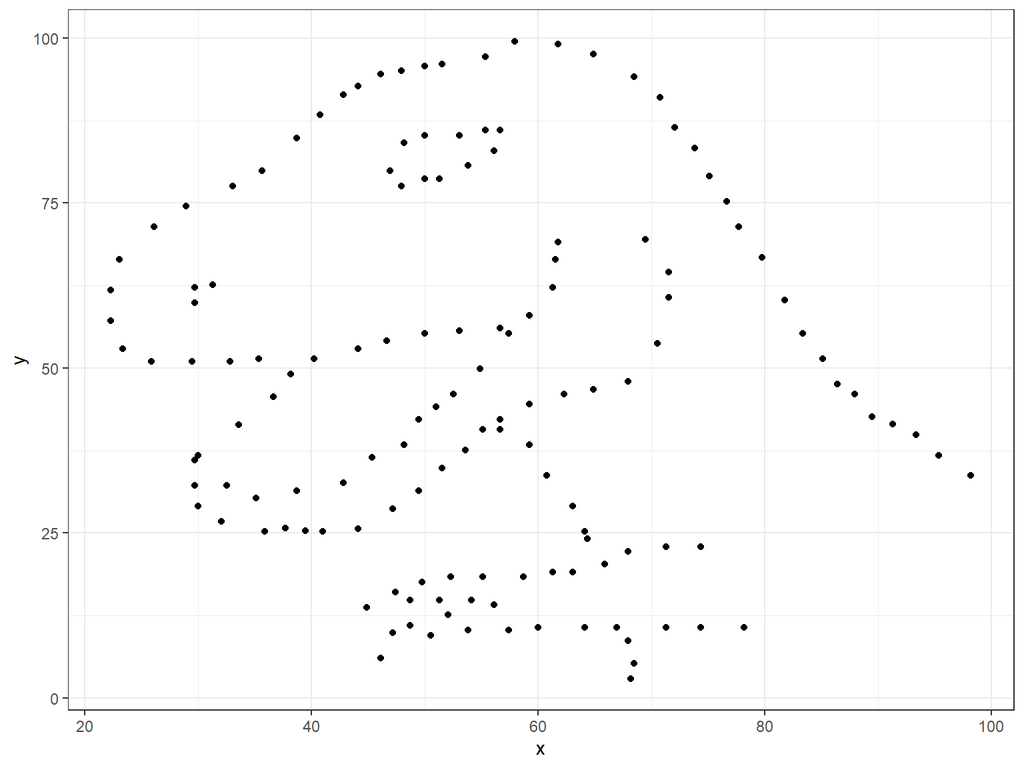

```r
dfd |>
  ggplot(
    aes(x = x, y = y)
  ) +
  geom_point() +
  theme_bw()
```

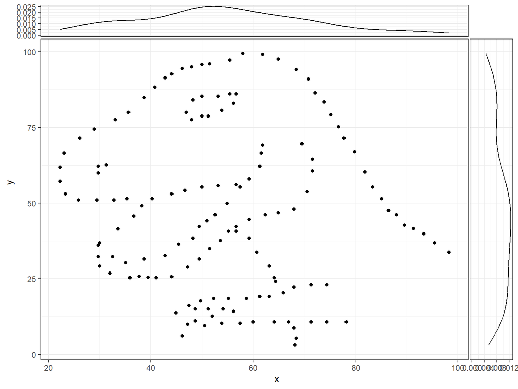

```r
library(ggside)

dfd |>
  ggplot(
    aes(x = x, y = y)
  ) +
  geom_point() +
  geom_xsidedensity() +
  geom_ysidedensity() +
  theme_bw()
```

## 3.2 Cvičení A

V prvním příkladu zkuste z tabulky starwars (v `dplyr`) vykreslit rozdělení (četnost) barvy očí (`eye_color`). Jedná se o diskrétní proměnnou, a proto je pro vykreslení množství vhodné sáhnout pro sloupcový graf.

**Zadání:** Vytvořte sloupcový graf zobrazující četnosti kategorií.

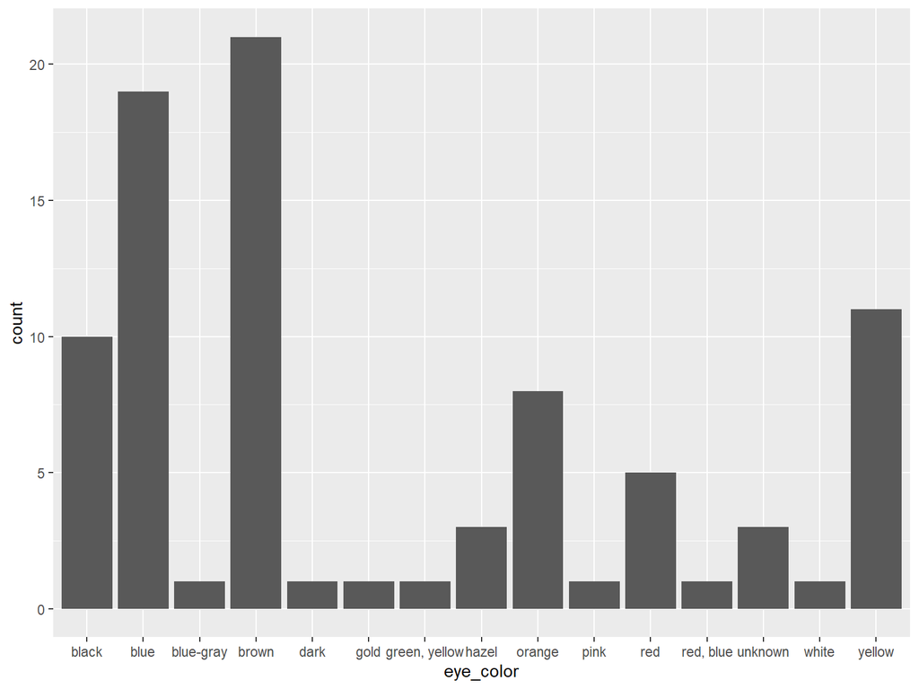

```r
# Sloupcový graf pro diskrétní proměnnou
starwars %>%
  ggplot(aes(x = eye_color)) +
  geom_bar()
```

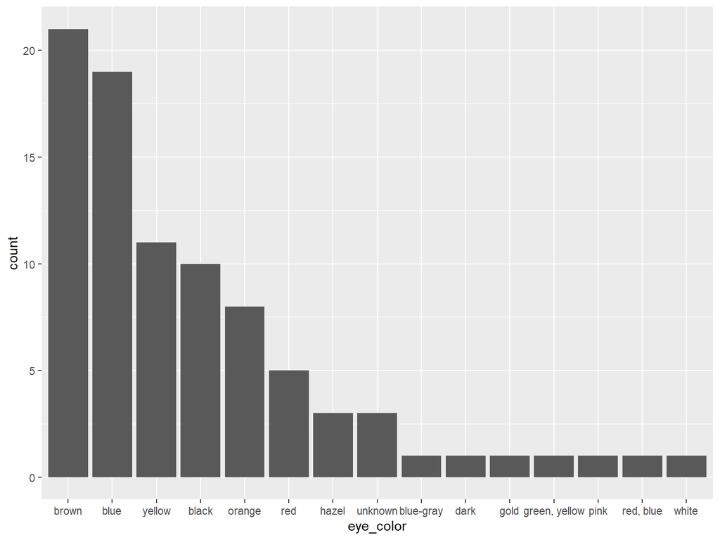

```r
# manualne zoradenie cez faktorizovany vektor
starwars %>%
  mutate(
    eye_color = factor(eye_color, levels = c(
      "brown","blue","yellow","black","orange","red","hazel","unknown",
      "blue-gray","dark","gold","green, yellow","pink","red, blue","white"
    ))
  ) %>%
  ggplot(aes(x = eye_color)) +
  geom_bar()
```

```r
# lepsie riesenie
## najprv rozdelit do grup a spocitat
starwars %>%
  group_by(eye_color) %>%
  summarise(obs = n()) # nefunguje obs = nrow(.)
```

```
#> # A tibble: 15 × 2
#>    eye_color       obs
#>    <chr>         <int>
#>  1 black            10
#>  2 blue             19
#>  3 blue-gray         1
#>  4 brown            21
#>  5 dark              1
#>  6 gold              1
#>  7 green, yellow     1
#>  8 hazel             3
#>  9 orange            8
#> 10 pink              1
#> 11 red               5
#> 12 red, blue         1
#> 13 unknown           3
#> 14 white             1
#> 15 yellow           11
```

```r
## potom zoradit
starwars %>%
  group_by(eye_color) %>%
  summarise(obs = n()) %>%
  arrange(desc(obs))
```

```
#> # A tibble: 15 × 2
#>    eye_color       obs
#>    <chr>         <int>
#>  1 brown            21
#>  2 blue             19
#>  3 yellow           11
#>  4 black            10
#>  5 orange            8
#>  6 red               5
#>  7 hazel             3
#>  8 unknown           3
#>  9 blue-gray         1
#> 10 dark              1
#> 11 gold              1
#> 12 green, yellow     1
#> 13 pink              1
#> 14 red, blue         1
#> 15 white             1
```

```r
## a takto zoradene priradim do levels
starwars %>%
  group_by(eye_color) %>%
  summarise(obs = n()) %>%
  arrange(desc(obs)) %>%
  mutate(eye_color = factor(eye_color, levels = eye_color))
```

```
#> # A tibble: 15 × 2
#>    eye_color       obs
#>    <fct>         <int>
#>  1 brown            21
#>  2 blue             19
#>  3 yellow           11
#>  4 black            10
#>  5 orange            8
#>  6 red               5
#>  7 hazel             3
#>  8 unknown           3
#>  9 blue-gray         1
#> 10 dark              1
#> 11 gold              1
#> 12 green, yellow     1
#> 13 pink              1
#> 14 red, blue         1
#> 15 white             1
```

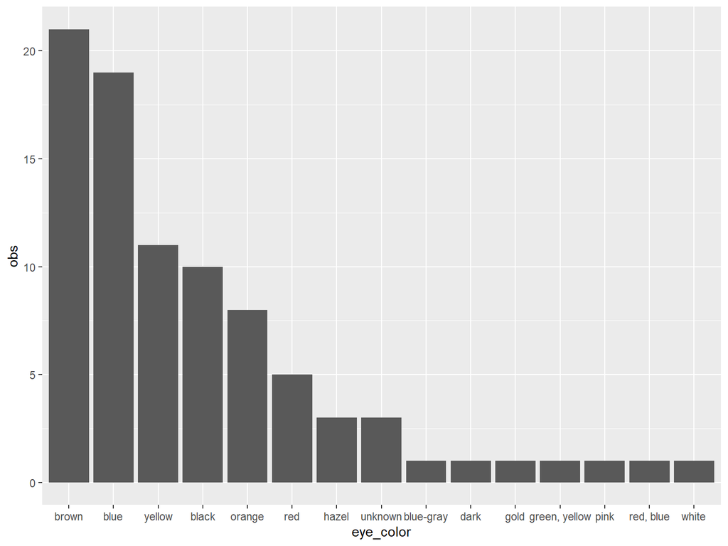

```r
starwars %>%
  group_by(eye_color) %>%
  summarise(obs = n()) %>%
  arrange(desc(obs)) %>%
  mutate(eye_color = factor(eye_color, levels = eye_color))%>%
  ggplot(aes(x = eye_color, y = obs)) +
  geom_col() # uz nemoze byt geom_bar, lebo to nevie pracovat s dvojicou
```

**Otázky k zamyšlení:** - Která kategorie je nejčetnější? - Existují kategorie s velmi nízkým počtem pozorování?

# 4 📈 Vizualizace rozdělení spojité proměnné

Spojité proměnné mohou nabývat nekonečně mnoho hodnot. Pro jejich vizualizaci používáme histogramy, hustotní grafy a box ploty.

## 4.1 Načtení dat

```r
# Načtěte data pro analýzu spojitých proměnných


# Základní statistiky
```

## 4.2 Cvičení B

**Zadání:** Vytvořte histogram pro spojitou proměnnou.

```r
# Histogram s vhodným počtem binů
```

**Otázky k zamyšlení:** - Jak vypadá rozdělení? (normální, zešikmené, bimodální?) - Jsou v datech extrémní hodnoty?

## 4.3 Cvičení C

**Zadání:** Vytvořte hustotní graf (density plot) pro spojitou proměnnou.

```r
# Hustotní graf
```

**Srovnání:** Jaké jsou výhody hustotního grafu oproti histogramu?

## 4.4 Cvičení D

**Zadání:** Vytvořte krabicový graf (box plot) pro spojitou proměnnou.

```r
# Krabicový graf
```

**Interpretace:** - Kde je medián? - Jaký je mezikvartilové rozpětí (IQR)? - Existují odlehlé hodnoty?

## 4.5 Cvičení E (s hvězdičkou) ⭐

**Zadání:** Vytvořte komplexní vizualizaci kombinující více typů grafů pro porovnání rozdělení spojité proměnné podle kategorií.

```r
# Kombinace histogramů/hustotních grafů podle kategorií
# Použijte faceting nebo překryvné grafy
```

**Bonusové úkoly:** - Přidejte průměry nebo mediány pro každou kategorii - Použijte různé barvy pro jednotlivé kategorie - Přidejte legendu a popisky

## 4.6 Cvičení F

**Zadání:** Vytvořte houslový graf (violin plot) pro porovnání rozdělení napříč kategoriemi.

```r
# Violin plot
```

**Interpretace:** Jaké informace poskytuje violin plot navíc oproti box plotu?

## 4.7 Cvičení G

**Zadání:** Vytvořte kombinovaný graf s box plotem a jednotlivými body (jittered points).

```r
# Box plot s překrytými body
```

**Poznámka:** Tento typ vizualizace je užitečný pro menší datasety, kde chceme vidět jak rozdělení, tak jednotlivá pozorování.

# 5 🔍 Vizualizace vztahů v rovině

Analýza vztahů mezi dvěma proměnnými je klíčovou částí EDA. Používáme scatter ploty, korelační grafy a další.

## 5.1 Načtení dat

```r
# Načtěte data pro analýzu vztahů


# Prozkoumejte strukturu
```

## 5.2 Cvičení H

**Zadání:** Vytvořte bodový graf (scatter plot) zobrazující vztah mezi dvěma spojitými proměnnými.

```r
# Scatter plot
```

**Otázky k zamyšlení:** - Existuje mezi proměnnými vztah? - Je vztah lineární nebo nelineární? - Jsou v datech outliers?

## 5.3 Cvičení I

**Zadání:** Přidejte do scatter plotu trendovou čáru.

```r
# Scatter plot s trendovou čárou (lineární i nelineární)
```

**Úkol:** Vypočítejte korelační koeficient:

```r
# Výpočet korelace
```

## 5.4 Cvičení J

**Zadání:** Vytvořte scatter plot s rozlišením podle třetí kategoriální proměnné (pomocí barvy nebo tvaru bodů).

```r
# Scatter plot s barevným rozlišením kategorií
```

**Analýza:** Liší se vztah mezi proměnnými podle kategorií?

## 5.5 Cvičení K

**Zadání:** Vytvořte matici scatter plotů (pairs plot) pro exploraci vztahů mezi více proměnnými.

```r
# Matice scatter plotů
# Můžete použít GGally::ggpairs() nebo základní pairs()
```

**Interpretace:** Které páry proměnných vykazují nejsilnější vztahy?

# 6 📊 Sumarizace dat

## 6.1 Popisné statistiky

```r
# Vypočítejte základní popisné statistiky
```

## 6.2 Seskupené statistiky

```r
# Vypočítejte statistiky podle skupin
```

# 7 🎨 Pokročilé techniky vizualizace

## 7.1 Ridge plots (pro porovnání hustot)

```r
# Použijte ggridges balík pro ridge plot
```

## 7.2 Hexbin plot (pro velké datasety)

```r
# Hexbin pro scatter plot s mnoha body
```

## 7.3 Korelační heatmapa

```r
# Vytvoření korelační matice a její vizualizace
```

# 8 💡 Důležité poznámky

## 8.1 Výběr správného typu grafu

| Účel | Typ dat | Vhodný graf |
| --- | --- | --- |
| Rozdělení jedné kategoriální proměnné | Diskrétní | Sloupcový graf (bar plot) |
| Rozdělení jedné spojité proměnné | Spojitá | Histogram, density plot |
| Porovnání rozdělení | Spojitá + kategorie | Box plot, violin plot |
| Vztah mezi dvěma spojitými | Spojitá + spojitá | Scatter plot |
| Vztah mezi spojitou a kategoriální | Spojitá + diskrétní | Box plot, violin plot |

## 8.2 Kontrola předpokladů

Při EDA kontrolujeme: - **Normalitu rozdělení** - histogram, Q-Q plot - **Outliers** - box plot, scatter plot - **Linearitu vztahů** - scatter plot - **Homoskedasticitu** - residual plots - **Chybějící hodnoty** - `summary()`, `is.na()`

## 8.3 Interpretace korelace

```r
# Korelační koeficient (Pearson)
cor(x, y)

# |r| < 0.3   → slabá korelace
# |r| 0.3-0.7 → střední korelace
# |r| > 0.7   → silná korelace
```

**POZOR:** Korelace ≠ kauzalita!

# 9 🔧 Užitečné funkce

## 9.1 Základní explorační funkce

```r
# Přehled datasetu
str(data)          # struktura
head(data)         # prvních 6 řádků
summary(data)      # popisné statistiky
glimpse(data)      # kompaktní přehled (dplyr)

# Kontrola chybějících hodnot
sum(is.na(data))
colSums(is.na(data))

# Unikátní hodnoty
unique(data$variable)
n_distinct(data$variable)
```

## 9.2 Popisné statistiky

```r
# Základní
mean(x, na.rm = TRUE)
median(x, na.rm = TRUE)
sd(x, na.rm = TRUE)
var(x, na.rm = TRUE)
quantile(x, probs = c(0.25, 0.75))
IQR(x, na.rm = TRUE)

# Rozsah
range(x, na.rm = TRUE)
min(x, na.rm = TRUE)
max(x, na.rm = TRUE)
```

## 9.3 Vizualizační tipy

```r
# Přidání průhlednosti pro překrývající se body
geom_point(alpha = 0.5)

# Jittering pro diskrétní data
geom_jitter(width = 0.2, height = 0)

# Faceting pro kategorie
facet_wrap(~ category)
facet_grid(rows ~ cols)

# Témata pro profesionální vzhled
theme_minimal()
theme_bw()
```

# 10 📈 EDA proces krok za krokem

## 10.1 1. Pochopení dat

- Načtení dat
- Kontrola rozměrů: `dim()`, `nrow()`, `ncol()`
- Přehled struktury: `str()`, `glimpse()`
- Názvy sloupců: `names()`, `colnames()`

## 10.2 2. Kontrola kvality dat

- Chybějící hodnoty: `summary()`, `is.na()`
- Duplicitní řádky: `duplicated()`
- Datové typy: kontrola, zda jsou správné
- Rozsah hodnot: logické minimum/maximum?

## 10.3 3. Univariátní analýza

Pro každou proměnnou: - Popisné statistiky - Vizualizace rozdělení - Identifikace outliers - Kontrola normalitu (pokud relevantní)

## 10.4 4. Bivariátní analýza

- Scatter ploty pro spojité proměnné
- Box ploty pro spojitou vs. kategoriální
- Korelační analýza
- Testy vztahů

## 10.5 5. Multivariátní analýza

- Matice scatter plotů
- Korelační heatmapy
- Facetované grafy
- Interakce mezi proměnnými

# 11 🎯 Checklist

- Rozumím rozdílu mezi diskrétními a spojitými proměnnými?
- Vím, jak vizualizovat rozdělení jedné proměnné?
- Dokážu porovnat rozdělení napříč kategoriemi?
- Umím analyzovat vztahy mezi dvěma proměnnými?
- Vím, jak identifikovat outliers a anomálie?
- Dokážu interpretovat korelační koeficienty?
- Umím vytvořit informativní a čitelné grafy?
- Chápu limitace korelační analýzy?

# 12 🔗 Užitečné odkazy

- [R for Data Science - EDA](https://r4ds.had.co.nz/exploratory-data-analysis.html)
- [ggplot2 documentation](https://ggplot2.tidyverse.org/)
- [GGally package](https://ggobi.github.io/ggally/) - pro pairs plots
- [ggridges package](https://wilkelab.org/ggridges/) - pro ridge plots
- [R Graph Gallery - Distribution](https://r-graph-gallery.com/distribution.html)
- [Correlation methods](https://www.statmethods.net/stats/correlations.html)

# 13 📚 Doporučená literatura

- **Wickham & Grolemund**: R for Data Science (kapitola 7: EDA)
- **Tukey, J. W.**: Exploratory Data Analysis (1977) - klasická práce
- **Healy, K.**: Data Visualization: A Practical Introduction

**Vytvorené pre:** MPE_AVED, Týždeň 10, ECON MUNI  
**Dátum:** 2025-12-03